# Airbnb San Diego

Diego Bermejo, Cristian Cardona, Ruben Ballesteros, Victor Canelo

26/4/2021

# Practica Airbnb San Diego

En esta práctica tenemos como objetivo tratar los datos del archivo de la página de Airbnb de la ciudad de San Diego, en este archivo se encuentran datos de todo tipo.

## Pregunta 1

En esta pregunta nos pedían cargar todos los datos del documento “listings.csv”. También nos pedían la selección de 10 variables para crear un dataframe con ellas. Para eliminar los símbolos ‘$’ y ‘,’ hemos utilizado el comando gsub y para transformar la columna en numérica hemos utilizado as.numeric

```r
listings <- read_csv("listings.csv" )
seleccion=c(27,30,32,33,34,37,38,40,41,42)
listings2=listings[,seleccion]
listings2$price=as.numeric(gsub(pattern="[\\$]|[,]",
                                replacement="",listings2$price))

listings3<- read_csv("NewYork.csv" )
listings3$price=as.numeric(gsub(pattern="[\\$]|[,]",
                                replacement="",listings3$price))
```

## Pregunta 2

En esta pregunta nos pedía la traducción de las variables que habíamos seleccionado, y estas son: el vecindario,la latitud,el tipo de propiedad,el tipo de habitación, la capacidad,el numero de habitaciones, las camas,el precio,las noches mínimas,las noches máximas. El cambio de nombre ha sido posible gracias a la función names.

```r
names(listings2)=c("Vecindario", "Latitud",
"Tipo_De_Propiedad","Tipo_De_Habitacion","Capacidad",
"Habitaciones","Camas","Precio","Noches_Minimas",
"Noches_Maximas")
str(listings2)
```

```
## tibble[,10] [9,286 x 10] (S3: tbl_df/tbl/data.frame)
##  $ Vecindario        : chr [1:9286] "San Diego, California, United States" NA "San Diego, California, United States" "La Jolla, California, United States" ...
##  $ Latitud           : num [1:9286] 32.8 32.8 32.7 32.8 32.8 ...
##  $ Tipo_De_Propiedad : chr [1:9286] "Entire condominium" "Entire bungalow" "Private room in house" "Entire guesthouse" ...
##  $ Tipo_De_Habitacion: chr [1:9286] "Entire home/apt" "Entire home/apt" "Private room" "Entire home/apt" ...
##  $ Capacidad         : num [1:9286] 6 8 1 3 2 2 2 2 2 1 ...
##  $ Habitaciones      : num [1:9286] 2 2 1 2 1 NA 1 1 1 1 ...
##  $ Camas             : num [1:9286] 4 3 1 3 1 0 0 1 1 1 ...
##  $ Precio            : num [1:9286] 2050 225 74 80 73 70 60 45 50 89 ...
##  $ Noches_Minimas    : num [1:9286] 3 4 1 4 1 1 30 2 2 3 ...
##  $ Noches_Maximas    : num [1:9286] 365 365 21 1125 30 ...
```

## Pregunta 3

En esta pregunta nos pedían que para las variables numéricas, calcularamos  
en una tabla los siguiente valores: mínimo, máximo, media, varianza, cuartiles y la mediana.

```r
estadisticos=function(x) c(A=min(x,na.rm=TRUE),B=max(x,na.rm=TRUE),
                           C=mean(x,na.rm=TRUE),D=var(x,na.rm=TRUE),
                           F=ifelse(is.na(table(is.na(x))[2]),0,
                                    table(is.na(x))[2]),
                           Q1=quantile(x,0.25,na.rm=TRUE),
                           Q2=quantile(x,0.50,na.rm=TRUE),
                           Q3=quantile(x,0.75,na.rm=TRUE))
#aggregate
salida=apply(listings2[,c( "Latitud","Capacidad",
"Habitaciones","Camas","Precio","Noches_Minimas",
"Noches_Maximas")],MARGIN=2,FUN=estadisticos)
rownames(salida)=c("Mínimo","Máximo","Media","Varianza","Na","Q1","Q2","Q3")
knitr::kable(salida,digits = 2)
```

|  | Latitud | Capacidad | Habitaciones | Camas | Precio | Noches_Minimas | Noches_Maximas |
| --- | --- | --- | --- | --- | --- | --- | --- |
| Mínimo | 32.53 | 0.00 | 1.00 | 0.00 | 0.00 | 1.00 | 1.00 |
| Máximo | 33.09 | 16.00 | 12.00 | 56.00 | 24999.00 | 365.00 | 16960.00 |
| Media | 32.77 | 4.73 | 1.91 | 2.52 | 235.81 | 6.21 | 581.11 |
| Varianza | 0.00 | 9.97 | 1.45 | 4.26 | 239157.64 | 245.20 | 308683.33 |
| Na | 0.00 | 0.00 | 989.00 | 39.00 | 0.00 | 0.00 | 0.00 |
| Q1 | 32.73 | 2.00 | 1.00 | 1.00 | 90.00 | 1.00 | 30.00 |
| Q2 | 32.76 | 4.00 | 2.00 | 2.00 | 142.00 | 2.00 | 365.00 |
| Q3 | 32.80 | 6.00 | 2.00 | 3.00 | 250.00 | 3.00 | 1125.00 |

## Pregunta 4

En esta pregunta nos pedían que para las variables no numéricas,creáramos  
tablas de frecuencias absolutas de cada uno de sus valores. Para ello hemos utilizado la función table y hemos visualizado los 10 valores más altos.

```r
sort(table(listings2$Vecindario),decreasing = TRUE)[1:10]
```

```
##
##   San Diego, California, United States Chula Vista, California, United States
##                                   6336                                    150
##    La Jolla, California, United States     Del Mar, California, United States
##                                     93                                     29
##       Tijuana, Baja California, Mexico      Bonita, California, United States
##                                      8                                      4
##   La Jolla , California, United States                      CA, United States
##                                      4                                      3
##   Escondido, California, United States          San Diego , Ca, United States
##                                      3                                      3
```

```r
sort(table(listings2$Tipo_De_Propiedad),decreasing = TRUE)[1:10]
```

```
##
##                Entire house            Entire apartment
##                        2109                        1859
##          Entire condominium       Private room in house
##                        1356                         899
##           Entire guesthouse          Entire guest suite
##                         393                         343
##            Entire townhouse              Entire cottage
##                         335                         255
##   Private room in apartment Private room in condominium
##                         248                         177
```

```r
sort(table(listings2$Tipo_De_Habitacion),decreasing = TRUE)[1:10]
```

```
##
## Entire home/apt    Private room     Shared room      Hotel room            <NA>
##            7260            1915              96              15
##            <NA>            <NA>            <NA>            <NA>            <NA>
##
```

## Pregunta 5

En esta pregunta nos pedían dibujar boxplots e histogramas de todas las variables numéricas. Para conseguir cumplir las condiciones del enunciado, hemos utilizado la función hist para conseguir los histogramas y para conseguir los boxplots hemos usado la función “boxplot” y para conseguir el numero de boxplots por  
filas hemos utilizado el comando: par(mfrow=c()).

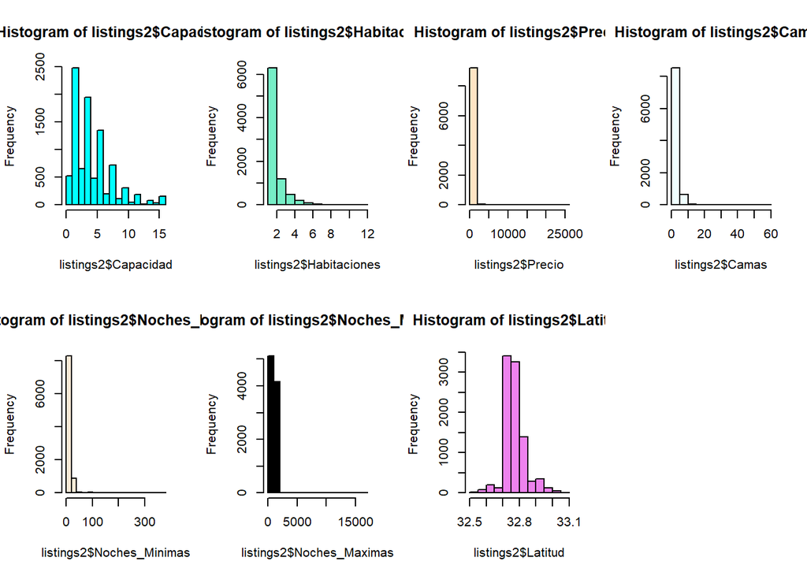

```r
par(mfrow=c(2,4))
hist(listings2$Capacidad,col="cyan")
hist(listings2$Habitaciones,col = "aquamarine2")
hist(listings2$Precio,col = "bisque")
hist(listings2$Camas,col = "azure")
hist(listings2$Noches_Minimas,col = "antiquewhite")
hist(listings2$Noches_Maximas,col="black")
hist(listings2$Latitud,col="violet")
par(mfrow=c(1,1))
```

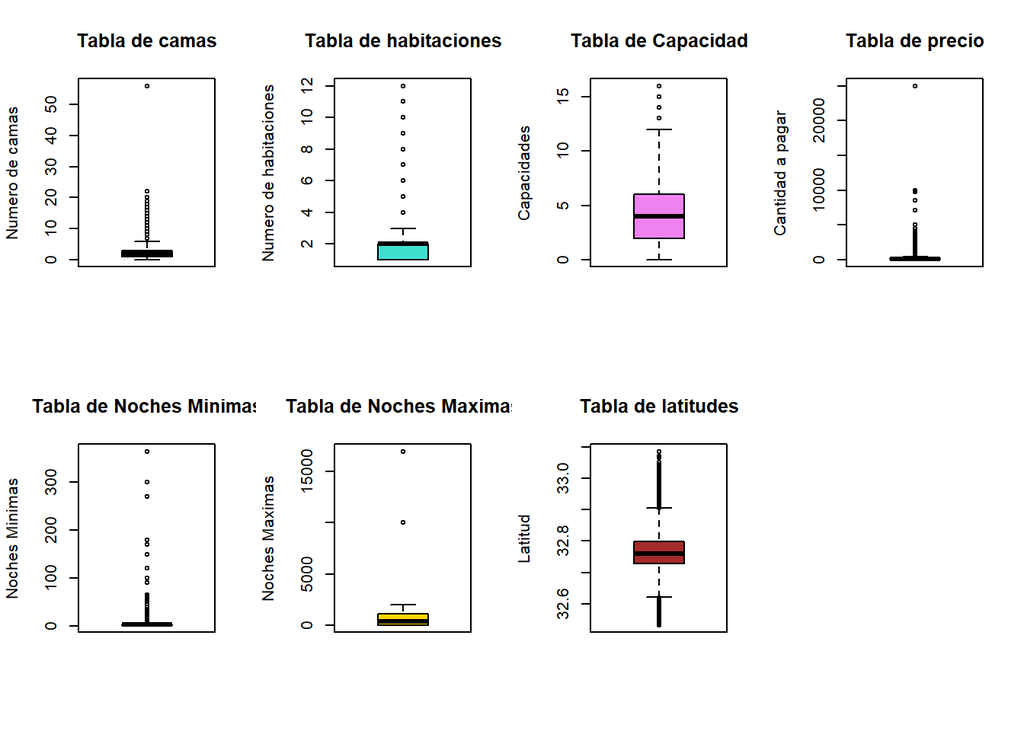

```r
par(mfrow=c(2,4))
boxplot(x=(listings2$Camas),main= "Tabla de camas",ylab="Numero de camas",
        col="purple")
boxplot(x=(listings2$Habitaciones),
        main= "Tabla de habitaciones",
        ylab="Numero de habitaciones",col="turquoise")
boxplot(x=(listings2$Capacidad),main= "Tabla de Capacidad",
        ylab="Capacidades",col = "violet")
boxplot(x=(listings2$Precio),main= "Tabla de precio",
        ylab="Cantidad a pagar",col="magenta")
boxplot(x=(listings2$Noches_Minimas),main= "Tabla de Noches Minimas",
        ylab="Noches Minimas",col="beige")
boxplot(x=(listings2$Noches_Maximas),main= "Tabla de Noches Maximas",
        ylab="Noches Maximas",col="gold")
boxplot(x=(listings2$Latitud),main= "Tabla de latitudes",
        ylab="Latitud",col="brown")
par(mfrow=c(1,1))
```

## Pregunta 6

```r
frec=c(listings2$Tipo_De_Habitacion)
aux=prop.table(table(frec))
aux
```

```
## frec
## Entire home/apt      Hotel room    Private room     Shared room
##     0.781822098     0.001615335     0.206224424     0.010338143
```

```r
otros=names(aux)[which(aux<=0.1)]
otros
```

```
## [1] "Hotel room"  "Shared room"
```

```r
frec[frec%in% otros]="Otros"
prop.table(table(frec))
```

```
## frec
## Entire home/apt           Otros    Private room
##      0.78182210      0.01195348      0.20622442
```

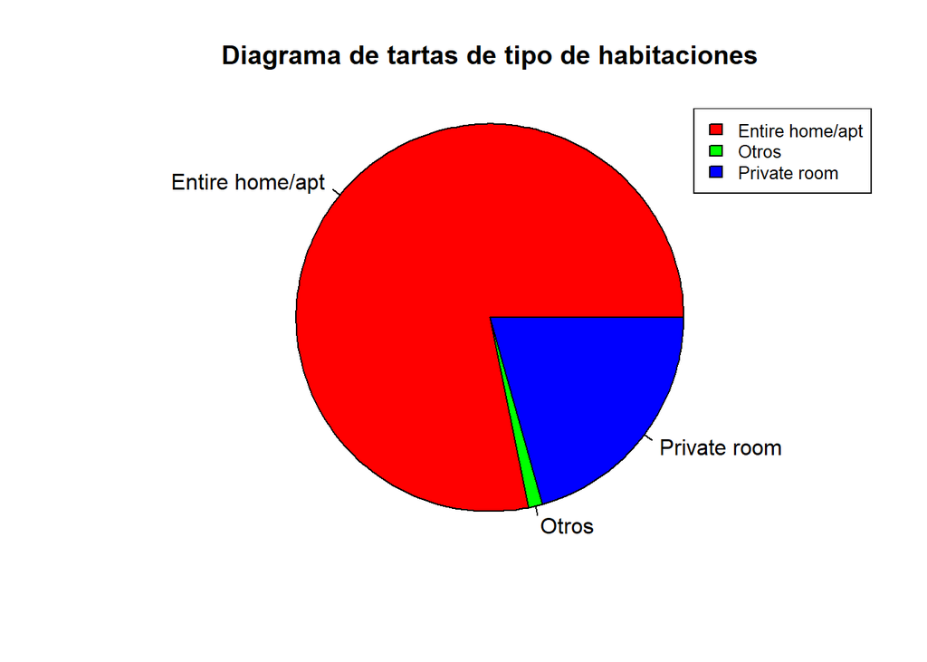

```r
pie(prop.table(table(frec)),
    radius=1,main="Diagrama de tartas de tipo de habitaciones",
    col=rainbow(n=3))

 legend("topright",
     c("Entire home/apt","Otros","Private room"), cex = 0.8,
     fill = rainbow(n=3))
```

## Pregunta 7

En este apartado se nos pedía calcular el valor medio de alguna de las variables numéricas según el barrio. Nosotros en este apartado hemos elegido las variables: habitaciones y el precio. Para calcular el valor medio hemos utilizado el na.omit para evitar que los valores NA entren a la hora de hacerlo y con la función mean obtenemos el resultado.

```r
data2=data.frame(Precio=listings2$Precio,Barrio=listings2$Vecindario)
class(data2$Barrio)
```

```
## [1] "character"
```

```r
data2=data2[ data2$Barrio != "" | data2$Barrio != "N/A",]
tabla_precios_barrio=aggregate(data2$Precio~data2$Barrio,
                               FUN=mean, na.action = na.omit )
names(tabla_precios_barrio)=c("Barrio","Precio de medio de Euros")
knitr::kable(tabla_precios_barrio,digits=2)
```

| Barrio | Precio de medio de Euros |
| --- | --- |
| Bonita, California, United States | 63.75 |
| CA, United States | 124.33 |
| Chula Vista (Eastlake), California, United States | 226.00 |
| Chula Vista , California, United States | 99.00 |
| Chula Vista, California, United States | 145.52 |
| Coronado, California, United States | 250.00 |
| Del Mar Highlands , California, United States | 60.00 |
| Del Mar, California, United States | 332.76 |
| Escondido, California, United States | 212.67 |
| Gas lamp San Diego, California, United States | 108.00 |
| La Jolla , California, United States | 205.00 |
| La Jolla Cove, California, United States | 254.00 |
| La Jolla, California, United States | 569.61 |
| LA JOLLA, California, United States | 997.00 |
| La Mesa, California, United States | 139.00 |
| Lemon Grove, California, United States | 45.00 |
| Mission Bay, California, United States | 275.00 |
| Mission Beach, California, United States | 300.50 |
| Ocean Beach, California, United States | 184.50 |
| Ocean Beach, San Diego, California, United States | 286.00 |
| Pacific Beach , California, United States | 99.00 |
| San Diego , Ca, United States | 160.33 |
| San Diego , California, United States | 87.50 |
| San Diego County, California, United States | 150.00 |
| San Diego, Ca, United States | 129.00 |
| San Diego, CA, United States, California, United States | 79.00 |
| San diego, California, United States | 102.00 |
| San Diego, California, United States | 217.89 |
| SAN DIEGO, California, United States | 140.00 |
| Santee, California, United States | 150.00 |
| Solana Beach, California, United States | 299.00 |
| Spring Valley, California, United States | 50.00 |
| Tijuana, Baja California, Mexico | 42.88 |

```r
data3=data.frame(Habitaciones=listings2$Habitaciones,
                 Barrio=listings2$Vecindario)
class(data3$Barrio)
```

```
## [1] "character"
```

```r
data3=data3[ data3$Barrio != "" | data3$Barrio != "N/A",]
tabla_habitaciones_barrio=aggregate(data3$Habitaciones~data3$Barrio,
                                    FUN=mean, na.action = na.omit )
names(tabla_habitaciones_barrio)=c("Barrio","Numero de Habitaciones")
knitr::kable(tabla_habitaciones_barrio,digits=2)
```

| Barrio | Numero de Habitaciones |
| --- | --- |
| Bonita, California, United States | 1.00 |
| CA, United States | 1.00 |
| Chula Vista (Eastlake), California, United States | 1.00 |
| Chula Vista , California, United States | 1.00 |
| Chula Vista, California, United States | 1.89 |
| Coronado, California, United States | 1.00 |
| Del Mar Highlands , California, United States | 1.00 |
| Del Mar, California, United States | 2.36 |
| Escondido, California, United States | 3.00 |
| Gas lamp San Diego, California, United States | 1.00 |
| La Jolla , California, United States | 2.00 |
| La Jolla Cove, California, United States | 2.00 |
| La Jolla, California, United States | 2.88 |
| LA JOLLA, California, United States | 5.00 |
| La Mesa, California, United States | 3.00 |
| Lemon Grove, California, United States | 1.00 |
| Mission Bay, California, United States | 2.00 |
| Mission Beach, California, United States | 3.00 |
| Ocean Beach, California, United States | 2.00 |
| Ocean Beach, San Diego, California, United States | 2.00 |
| Pacific Beach , California, United States | 1.00 |
| San Diego , Ca, United States | 1.67 |
| San Diego , California, United States | 1.00 |
| San Diego County, California, United States | 1.00 |
| San Diego, CA, United States, California, United States | 1.00 |
| San diego, California, United States | 1.00 |
| San Diego, California, United States | 1.89 |
| SAN DIEGO, California, United States | 1.00 |
| Santee, California, United States | 3.00 |
| Solana Beach, California, United States | 3.00 |
| Spring Valley, California, United States | 1.00 |
| Tijuana, Baja California, Mexico | 1.12 |

## Pregunta 8

```r
tabla_precios_medios=aggregate(Precio~Vecindario,data=listings2,FUN=function(x)
  mean(x,na.rm=TRUE))
tabla_precios_medios=na.omit(tabla_precios_medios[order(
  tabla_precios_medios$Precio),])

cinco_baratos=tabla_precios_medios$Vecindario[1:5]
n=dim(tabla_precios_medios)[1]
n
```

```
## [1] 33
```

```r
cinco_caros=tabla_precios_medios$Vecindario[(n-4):n]
cinco_baratos
```

```
## [1] "Tijuana, Baja California, Mexico"
## [2] "Lemon Grove, California, United States"
## [3] "Spring Valley, California, United States"
## [4] "Del Mar Highlands , California, United States"
## [5] "Bonita, California, United States"
```

```r
cinco_caros
```

```
## [1] "Solana Beach, California, United States"
## [2] "Mission Beach, California, United States"
## [3] "Del Mar, California, United States"
## [4] "La Jolla, California, United States"
## [5] "LA JOLLA, California, United States"
```

```r
dos_precios=na.omit(listings2[listings2$Vecindario %in% c(cinco_baratos,cinco_caros),c("Precio","Vecindario")])
```

```r
dos_precios$caro=factor(dos_precios$Vecindario %in% cinco_caros,
                        labels = c("Barato","Caro"))
head(dos_precios,10)
```

| Precio | Vecindario | caro |
| --- | --- | --- |
| 80 | La Jolla, California, United States | Caro |
| 650 | La Jolla, California, United States | Caro |
| 1324 | La Jolla, California, United States | Caro |
| 161 | La Jolla, California, United States | Caro |
| 171 | La Jolla, California, United States | Caro |
| 187 | La Jolla, California, United States | Caro |
| 191 | La Jolla, California, United States | Caro |
| 250 | La Jolla, California, United States | Caro |
| 2750 | La Jolla, California, United States | Caro |
| 330 | Del Mar, California, United States | Caro |

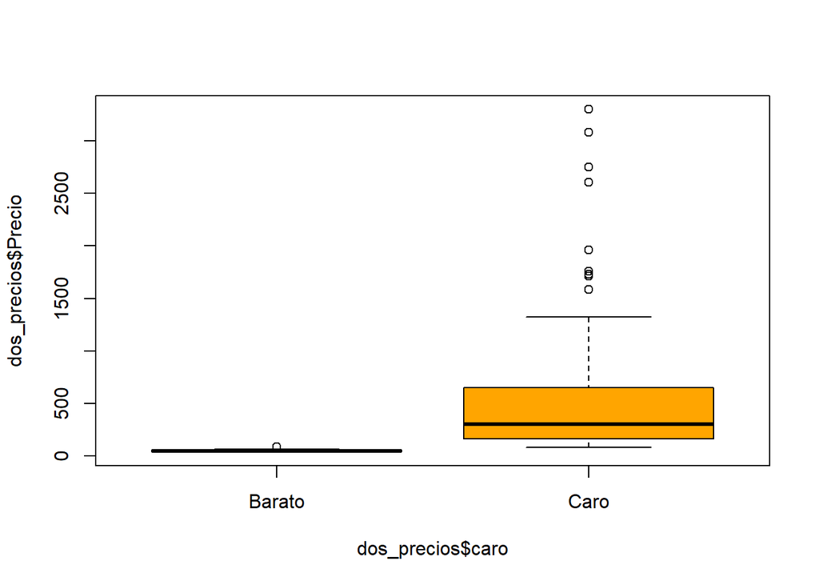

```r
boxplot(dos_precios$Precio~dos_precios$caro,col="orange")
```

## Pregunta 9

En este apartado se nos plantea el siguiente enunciado:dibujar diagramas de dispersión para 4 de las variables numéricas con colores diferentes para cada barrio.Para ello hemos utilizado la función plot y para cumplir las condiciones que nos piden hemos utilizado par(mfrow=c())

```r
n=length(unique(listings2$Vecindario))
n# numero zonas
```

```
## [1] 34
```

[figure not shown]

```r
par(mfrow=c(3,2))
plot(listings2$Precio,listings2$Noches_Minimas,
     main = "Diagrama Noches Minimas ",
      pch = 21, bg = rainbow(n)[factor(listings2$Vecindario)],
     xlab="Vecindario",ylab="Numero de Noches Minimas")

plot(listings2$Precio,listings2$Noches_Maximas, main = "Noches Maximas ",
        pch = 21, bg = rainbow(n)[factor(listings2$Vecindario)],
     xlab="Vecindario",ylab="Numero de Noches Maximas")
plot(listings2$Precio,listings2$Habitaciones, main = "Habitaciones ",
      pch = 21, bg = rainbow(n)[factor(listings2$Vecindario)],
     xlab="Vecindario",ylab="Numero de Habitaciones")

plot(listings2$Precio,listings2$Camas, main = "Camas ",
      pch = 21, bg = rainbow(n)[factor(listings2$Vecindario)],
     xlab="Vecindario",ylab="Numero de Camas")
par(mfrow=c(1,1))
```

## Pregunta 10

En este apartado nos piden calcular los coeficientes de correlación de las variables del apartado anterior sin tener en cuenta los valores NA. Nosotros al escoger la mayoría de variables de manera voluntaria, hemos escogido para este ejercicio la latitud, las habitaciones, el precio y las camas . Para realizar esta pregunta hemos utilizado la función cor y hemos saltado los valores mediante el comando use=“na.or.complete”.

```r
cor(listings2$Latitud,listings2$Habitaciones,use="na.or.complete")
```

```
## [1] 0.1113529
```

```r
cor(listings2$Precio,listings2$Camas,use="na.or.complete")
```

```
## [1] 0.2940944
```

## Pregunta 11

```r
IntervaloPrecios5<-cut(listings2$Precio,breaks=c(0,100,200,300,Inf))
str(IntervaloPrecios5)
```

```
##  Factor w/ 4 levels "(0,100]","(100,200]",..: 4 3 1 1 1 1 1 1 1 1 ...
```

```r
table(IntervaloPrecios5)
```

```
## IntervaloPrecios5
##   (0,100] (100,200] (200,300] (300,Inf]
##      2949      3331      1239      1763
```

```r
IntervaloCapacidad5<-cut(listings2$Capacidad,breaks=c(1,2,3,4,10,Inf))
str(IntervaloCapacidad5)
```

```
##  Factor w/ 5 levels "(1,2]","(2,3]",..: 4 4 NA 2 1 1 1 1 1 NA ...
```

```r
table(IntervaloCapacidad5)
```

```
## IntervaloCapacidad5
##    (1,2]    (2,3]    (3,4]   (4,10] (10,Inf]
##     2484      654     1945     3170      508
```

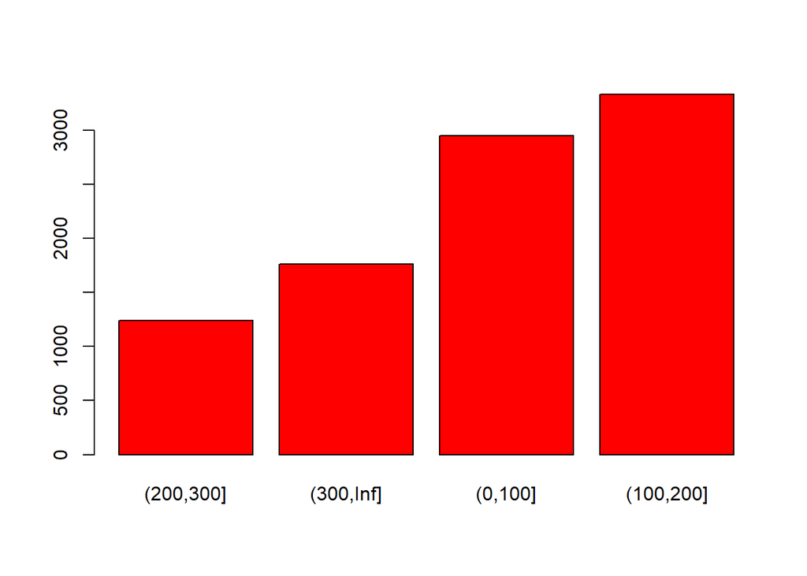

```r
barplot(sort(table(IntervaloPrecios5)),col="red")
```

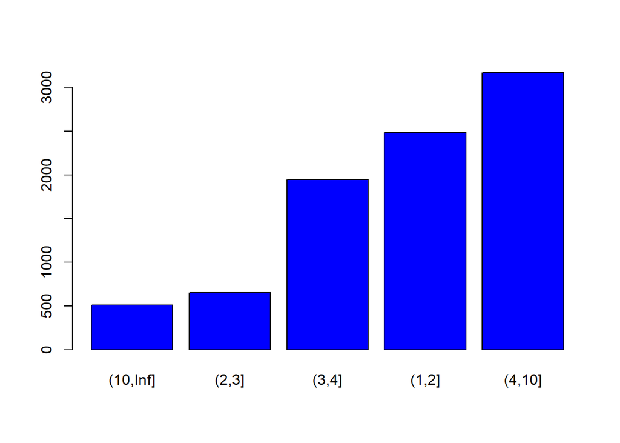

```r
barplot(sort(table(IntervaloCapacidad5)),col="blue")
```

## Pregunta 12

En esta pregunta se nos pide que creemos una tabla de contingencia con las variables anteriores y dibujar un diagrama de mosaico. Para realizar este apartado hemos utilizado la función table con las variables IntervaloPrecio5 e IntervaloCapacidad5 calculados el apartado anterior, y para conseguir el gráfico, hemos hecho uso de la función mosaicplot y hemos introducido la variable tabla_mosaico

```r
tabla_mosaico=table(IntervaloPrecios5,IntervaloCapacidad5)
tabla_mosaico
```

```
##                  IntervaloCapacidad5
## IntervaloPrecios5 (1,2] (2,3] (3,4] (4,10] (10,Inf]
##         (0,100]    1559   306   474    147        5
##         (100,200]   742   314  1090   1111       26
##         (200,300]   108    24   233    817       52
##         (300,Inf]    75    10   148   1095      425
```

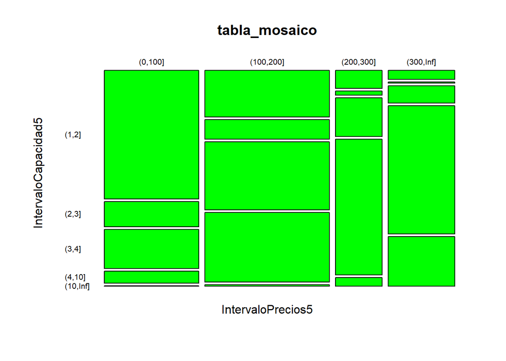

```r
mosaicplot(tabla_mosaico,color="green",las = 0.5,off=5)
```

## Parte 2

## Pregunta 1

En esta pregunta se nos pide que calculemos el estimador de la media muestral y el error estandar.

```r
media_del_precio=mean(listings2$Precio,na.rm = TRUE)
media_del_precio
```

```
## [1] 235.8146
```

```r
sd_del_precio=sd(listings2$Precio,na.rm = TRUE)
sd_del_precio
```

```
## [1] 489.0375
```

```r
n= length(listings2$Precio)
error_estandar= sd_del_precio/sqrt(n)
error_estandar
```

```
## [1] 5.074904
```

## Pregunta 2

En esta pregunta se nos pide calcular el intervalo de confianza al 95% de la variable precio de nuestro dataframe.

```r
t.test(listings2$Precio,conf.level = 0.95)
```

```
##
##  One Sample t-test
##
## data:  listings2$Precio
## t = 46.467, df = 9285, p-value < 2.2e-16
## alternative hypothesis: true mean is not equal to 0
## 95 percent confidence interval:
##  225.8666 245.7625
## sample estimates:
## mean of x
##  235.8146
```

Para resolución de este apartado hemos utilizado el t.test de la variable Precio del dataframe listings2. Cómo el estadístico de contraste t=46.467 no se encuentra entre los valores (225.8666,245.7625) tenemos evidencias suficientes para rechazar la hipotesis nula,H0.

## Pregunta 3

```r
head(listings$review_scores_rating)
```

```
## [1] NA 98 86 99 96 97
```

```r
q75=quantile(listings$review_scores_rating,0.75,na.rm = TRUE)
review98=listings$review_scores_rating<q75
phat=prop.table(table(review98))[2]
```

```r
names(phat)=NULL
phat
```

```
## [1] 0.6560697
```

```r
ni=length(review98)
ni
```

```
## [1] 9286
```

```r
alpha=1-0.99
alpha
```

```
## [1] 0.01
```

```r
zq=1-alpha/2
zq
```

```
## [1] 0.995
```

```r
qnt=qnorm(zq)
qnt
```

```
## [1] 2.575829
```

```r
error=sqrt(phat*(1-phat)/ni)
error
```

```
## [1] 0.00492942
```

```r
c(phat-zq*error,phat+zq*error)
```

```
## [1] 0.6511650 0.6609745
```

## Pregunta 4

En esta pregunta se nos pide que supongamos que un responsable de Airbnb asegura que la media de los valores de review_scores_rating de las viviendas de su portal es superior a 95. Contrastad esta hipótesis.

```r
t.test(listings$review_scores_rating,mu=95,alternative = "less")->sol.test
sol.test
```

```
##
##  One Sample t-test
##
## data:  listings$review_scores_rating
## t = 1.8173, df = 7800, p-value = 0.9654
## alternative hypothesis: true mean is less than 95
## 95 percent confidence interval:
##      -Inf 95.28794
## sample estimates:
## mean of x
##  95.15113
```

## Pregunta 5

En esta pregunta se nos pide calcular el intervalo de confianza,del 95% asociado al contraste del ejercicio anterior.

```r
sol.test$conf.int
```

```
## [1]     -Inf 95.28794
## attr(,"conf.level")
## [1] 0.95
```

Para resolución de este apartado hemos visualizado la variable sol.test que era el vector guardado del ejercicio anterior. Cómo el estadístico de contraste t=1.8173 se encuentra entre los valores (-inf,95.28794) tenemos evidencias suficientes para no rechazar la hipotesis nula,H0.

## Pregunta 6

En esta pregunta se nos pide hagamos un contraste de hipótesis para decidir si las desviaciones típicas de los precios de las dos ciudades son iguales o diferentes.

```r
var.test(listings2$Precio,listings3$price)
```

```
##
##  F test to compare two variances
##
## data:  listings2$Precio and listings3$price
## F = 2.8363, num df = 9285, denom df = 36904, p-value < 2.2e-16
## alternative hypothesis: true ratio of variances is not equal to 1
## 95 percent confidence interval:
##  2.746896 2.929517
## sample estimates:
## ratio of variances
##           2.836292
```

Para resolución de este apartado hemos utilizado un var.test de las variables Precio del dataframe listings2 y la variable price del dataframe listings3. Cómo el p-valor es practicamente 0 y por lo tanto,menor que 0.05, tenemos evidencias suficientes para rechazar la hipotesis nula,H0.

## Pregunta 7

En esta pregunta nos preguntaba que a partir de los resultados del apartado anterior contratad la hipótesis de que los precios medios en las dos ciudades son iguales.

```r
SANDIEGO<-listings2$Precio
NY<-listings3$price
t.test(x=SANDIEGO,y=NY)
```

```
##
##  Welch Two Sample t-test
##
## data:  SANDIEGO and NY
## t = 16.478, df = 10984, p-value < 2.2e-16
## alternative hypothesis: true difference in means is not equal to 0
## 95 percent confidence interval:
##  76.87568 97.63489
## sample estimates:
## mean of x mean of y
##  235.8146  148.5593
```

```r
sd(SANDIEGO)^2/sd(NY)^2
```

```
## [1] 2.836292
```

Para resolución de este apartado hemos utilizado un t.test de las variables Precio del dataframe listings2 y la variable price del dataframe listings3. Cómo el p-valor es practicamente 0 y por lo tanto,menor que 0.05, tenemos evidencias suficientes para rechazar la hipotesis nula,H0.

## Pregunta 8

```r
nortest::lillie.test(listings3$price)
```

```
##
##  Lilliefors (Kolmogorov-Smirnov) normality test
##
## data:  listings3$price
## D = 0.32815, p-value < 2.2e-16
```

Para resolución de este apartado hemos utilizado un lillie.test de la variable price del dataframe listings3. Cómo el p-valor es practicamente 0 y por lo tanto,menor que 0.05, tenemos evidencias suficientes para rechazar la hipotesis nula,H0.

# Pregunta 9

En esta pregunta se nos pide que analicemos la dependencia entre las variables Price y review_scores_rating de la ciudad que tiene asignada.

```r
breaks_1=c(min(listings2$Precio),quantile(listings2$Precio,c(0.25,0.5,0.75)),
           max(listings2$Precio))
breaks_1
```

```
##         25%   50%   75%
##     0    90   142   250 24999
```

```r
breaks_2=fivenum(listings$review_scores_rating)
breaks_2
```

```
## [1]  20  94  97  99 100
```

```r
clases_price=cut(listings2$Precio,breaks=breaks_1)
head(clases_price)
```

```
## [1] (250,2.5e+04] (142,250]     (0,90]        (0,90]        (0,90]
## [6] (0,90]
## Levels: (0,90] (90,142] (142,250] (250,2.5e+04]
```

```r
levels(clases_price)
```

```
## [1] "(0,90]"        "(90,142]"      "(142,250]"     "(250,2.5e+04]"
```

```r
clases_score=cut(listings$review_scores_rating,breaks=breaks_2)
head(clases_score)
```

```
## [1] <NA>    (97,99] (20,94] (97,99] (94,97] (94,97]
## Levels: (20,94] (94,97] (97,99] (99,100]
```

```r
levels(clases_score)
```

```
## [1] "(20,94]"  "(94,97]"  "(97,99]"  "(99,100]"
```

```r
tabla=table(clases_price,clases_score)
tabla
```

```
##                clases_score
## clases_price    (20,94] (94,97] (97,99] (99,100]
##   (0,90]            574     518     513      499
##   (90,142]          608     494     441      435
##   (142,250]         562     512     399      449
##   (250,2.5e+04]     506     401     325      543
```

```r
chisq.test(x=clases_price,y=clases_score)
```

```
##
##  Pearson's Chi-squared test
##
## data:  clases_price and clases_score
## X-squared = 61.027, df = 9, p-value = 8.498e-10
```